# [ML]ModelSummay

机器学习各种模型总结，考虑如何统一各种算法的形式，总结一下模型的loss function，regularization，统一描述部分模型

## 模型总结

前边已经说了很多算法：Linear Regression，Logistic Regression, SVM等等。但是我们没有考虑过这些看似不同算法背后的联系，所以现在看来如果遇到一个新问题，我们都需要把整个问题审视一下，然后再把这个问题的公式推导一遍，最后代码实现。显然这不是我们期待的，没有对这些算法抽象出一个统一的视角去看待它。所以下面的目标就是进行抽象统一：  
既然要统一，就得从算法的纯粹代数结构去看，不再关心几何的东西，几何认识和模型的关联性太强，不方便抽象。比如你就不要再想着SVM算法是把不同类别的点用一条直线或者是超平面尽可能的分开。先把一些算法推导出来的最终需要解决的方程组列出来：

**Linear Regression**
Model： $$f(x)\mathbf{}=\mathbf{\theta^{T}x }$$ Object function: $$J=\sum_{i}^{n}(y-f(\mathbf{x}))^{2}+\frac{1}{2}\left \| \mathbf{\theta} \right \|^{2}$$

**Logistic Regression**
Model: $$P(y=1|\mathbf{x})=\frac{1}{1+\mathbf{e^{-\theta^Tx}}}$$ $$P(y=0|\mathbf{x})=\frac{\mathbf{e^{-\theta^Tx}}}{1+\mathbf{e^{-\theta^Tx}}}$$ Object function: $$J=-\sum_{i}y_ilogP(y_i=1 \mid \mathbf{x_i})+(1-y_i)logP(y_i=0 \mid \mathbf{x_i})+\frac{1}{2}\left \| \mathbf{\theta} \right \|^{2}$$

**SVM**
Model： $$f(x)\mathbf{}=\mathbf{\theta^{T}x }$$ Object function： $$\left\{\begin{align*} & min_{\theta ,c_i} \frac{1}{2}\left \| \mathbf{\theta } \right \|^{2} + C\sum_i^nc_i \\ & y_i(\theta^T x_i + b) \ge 1-c_i \\ & c_i \ge 0 \end{align*}\right. $$

首先我们看上边的Object function, 我们可以发现里边都有一个$\frac{1}{2}\left \| \mathbf{\theta} \right \|^{2}$，这个你应该记得，这是Regularization Item正则化项，当然你还可以把这个L2正则化项替换成其他的，比如L1。所以这个Object function可以写成两项之和，一项是正则化项，另一项先说出来无妨，它就是损失函数。

先介绍最原始的损失函数（损失函数就是衡量模型做错事情的程度，错得深不深）。那么最简单的就是计数，如果模型把一个样本给弄错了，那就给他记过一次，没有做错就忽略。最终的目标就是让错误的次数求和最小。这就是0-1损失函数：弄错计1，没弄错计0；用公式写下来就是： $$L=\sum_i^nis(模型对样本x_i处理错误)$$

(is代表里边的表达式为真就等于1，为假就等于0)超级简单，自然的结果，可是要优化这个$L$不简单，因为这个函数都不连续，更不用谈求导使用牛逼的微积分工具了。所以我们的目标就是要找个替代函数，保证和0-1损失函数要描述的事情相同（错得越深损失越大），而且还要能够适应优化算法（差不多就是曲线光滑连续可求导，其实要求也不用这么严格，比如下边要说的hinge损失），然后呢，正好就有这么些个函数形状满足要求，函数也不复杂(这里留意下，我们主要关心函数在自变量=0的两侧附近像不像0-1损失函数)： $$ \left\{\begin{align*} & 指数损失 & y=e^{-x} \\ & 平方损失 & y=(x-1)^2 \\ & hinge损失 & y=max(0, 1-x) \\ & Logistic损失 & y=log(1+e^{-x}) \end{align*}\right. $$ 我把这几个函数的图像画出来看看

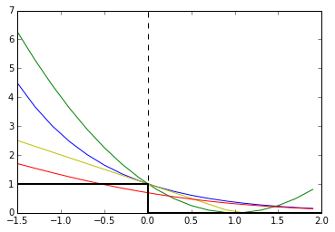

```python
import numpy as np
import matplotlib.pyplot as plt
x=np.arange(-1.5,2,0.2)
y1=np.exp(-x)
y2=(x-1)**2
y3=1-x
y3[y3<0]=0
y4=np.log(1+np.exp(-x))
%matplotlib inline
plt.plot(x, y1, 'b-') #指数损失
plt.plot(x, y2, 'g-') #平方损失
plt.plot(x, y3, 'y-') #hinge损失
plt.plot(x, y4, 'r-') #Logistic损失
plt.plot([-1.5, 0, 0, 2],[1,1,0,0], 'k-',lw=2) #0-1损失
plt.plot([0,0],[-0,7], 'k',linestyle='--')
plt.show()
```

下面我们就一个一个看，是不是它们能和我们的模型对应起来。
**Linear Regression**
没得说了，直接就是平方损失。
**Logistic Regression**
把这堆东西拿来处理一下，$-y_ilogP(y_i=1 \mid \mathbf{x_i})+(1-y_i)logP(y_i=0 \mid \mathbf{x_i})$，把P的具体形式代入进去，然后为了看着清晰，我就不写下角标了。 $$-\left ( ylog\frac{1}{1+e^{-\mathbf{\theta^T x}}} +(1-y)log\frac{e^{-\mathbf{\theta^T x}}}{1+e^{-\mathbf{\theta^T x}}} \right )$$

**SVM**
svm原始的Object function其实不是酱紫的： $$\left\{\begin{align*} & min_{\theta ,c_i} \frac{1}{2}\left \| \mathbf{\theta } \right \|^{2} + C\sum_i^n{c_i} \\ & y_i(\theta^T x_i + b) \ge 1-c_i \\ & c_i \ge 0 \end{align*}\right. $$

从这个式子表达的意思来看，是说要让每个点跑到这两根直线$\mathbf{\theta^Tx}+b=\pm 1$中间去的距离不能太大了，超出一丝丝没问题，多了就怒了。但是原式的Object function表达的意思是跑到这俩直线中间去的点的个数不能太多了，一个是限制的距离，一个是限制的点个数，还是有点区别的。然后原始的Object function是长这样的： $$\left\{\begin{align*} & min_{\theta ,c_i} \frac{1}{2}\left \| \mathbf{\theta } \right \|^{2} + C\sum_i^nis(y_i(\theta^T x_i + b) < 1) \\ & y_i(\theta^T x_i + b) \ge 1 \end{align*}\right. $$

上边说过了，0-1形式的损失函数是不大好的，所以我们需要把上边这个函数$is(y_i(\theta^T x_i + b) < 1)$替换一下，然后呢$y_i(\theta^T x_i + b)$这串东西小于1了，就给他计算损失，大于1一点事儿没有。正好$y=max(0, 1-x)$这个函数性质是不是很像，$x<1$了就大于0，$x \ge 1$了为0。有没有很激动，继续，用hinge损失把上边的is函数替换掉就是酱紫了(不写下角标了)： $$ is(y(\theta^T x + b) < 1) \rightarrow max(0, 1 - y(\theta^T x + b)) $$

因为我们的目标是求这个的最小值$max(0, 1 - y(\theta^T x + b))$，所以我们找一个$max(0, 1 - y(\theta^T x + b))$的上界，如果这个上界被优化得很小了，那么$max(0, 1 - y(\theta^T x + b))$也会很小，可以理解吧。假设这个上界就是$c$（不是大写C）,那么就有： $$max(0, 1 - y(\theta^T x + b)) < c$$ 因此 $$1 - y(\theta^T x + b) < c 且 c > 0$$

把这几个条件综合起来是不是就变成熟悉的这个了？ $$\left\{\begin{align*} & min_{\theta ,c_i} \frac{1}{2}\left \| \mathbf{\theta } \right \|^{2} + C\sum_i^nc_i \\ & y_i(\theta^T x_i + b) \ge 1-c_i \\ & c_i \ge 0 \end{align*}\right. $$ 我勒个去，终于说明白了，好辛苦啊。

最后总结一下，我们说了半天的这堆东西有什么好处。好处就是我们可以把模型的求解拆分成两个模块了，一个就是损失函数，另一个是正则化项。然后我们把求解不同的损失函数的代码模块写好，同样解不同正则化项的代码模块写好，当我们拿到一堆数据之后，假设我们的遇到的case直觉上判断应该符合logistic回归模型。那么我们就不用再管中间过程怎么推导的了，我们先把数据稍作处理，该归一化归一化，最重要的是，我们上边写的logistic回归模型对y的要求是1,0两个值，所以你只要把可以求解logistic损失函数的代码拿过来就可以开始搞起了。然后完了，你发现好像使用logistic回归模型效果不太好，想用SVM，很简单，把y重新处理成1、-1两个值，在把SVM的代码模块拿过来，再运行一遍就ok了。最后说一嘴，当你选择了什么损失函数，差不多就意味着你的数据符合对应的模型，他们俩已经关联在一块儿了。